# iDEP: Investigating Differentially Expressed Genes

## If this site has contributed to your work, please cite our article:

Ge, S.X., Son, E.W. & Yao, R. iDEP: an integrated web application for differential expression and pathway analysis of RNA-Seq data. BMC Bioinformatics 19, 534 (2018). https://doi.org/10.1186/s12859-018-2486-6

## Summary

Read Counts data were analyzed using iDEP v2.4.4. The data was first filtered to remove reads below 0.5 CPM in at least 1 sample. Then the data was transformed with EdgeR using a pseudocount of 4. Missing values were imputed using geneMedian.

After mapping, there are 32833 unique genes in 158 samples. Of the 24127 genes passed filter, 24127 were converted to Ensembl/STRING gene IDs in our database. The remaining 0 genes were kept in the data using original IDs.

Differential expression analysis was performed using DESeq2 with an FDR cutoff of 0.1 and a minimum fold-change threshold of 2. Standard Wald test was used and independent filtering was enabled.

## Selected Comparison: Time_After_Treatment_min1440-Time_After_Treatment_min0

Up-regulated genes: 431

Down-regulated genes: 317

## Top Up-regulated Genes

```r
if (!is.null(params$up_genes_table) && nrow(params$up_genes_table) > 0) {
  kbl(params$up_genes_table, escape = FALSE) %>%
    kable_classic(full_width = FALSE, html_font = "Cambria")
} else {
  print("No up-regulated genes found for this comparison.")
}
```

| Symbol | Ensembl ID | log2 FC | Adj. P-value | Description |
| --- | --- | --- | --- | --- |
| AT2G09785 | AT2G09785 | 18.644 | 2.99e-05 | NcRNA |
| AT1G04163 | AT1G04163 | 14.647 | 6.13e-04 | NcRNA |
| AT1G07500 | AT1G07500 | 12.851 | 2.54e-14 | Uncharacterized protein |
| MRD1 | AT1G53480 | 12.380 | 2.86e-10 | Mto 1 responding down 1 |
| AT1G05767 | AT1G05767 | 11.639 | 1.20e-09 | S-adenosyl-L-methionine-dependent methyltransferases superfamily protein |
| LTP4 | AT5G59310 | 5.993 | 4.37e-03 | Lipid transfer protein 4 |
| AT5G15500 | AT5G15500 | 5.851 | 2.02e-06 | Ankyrin repeat family protein |
| CYP82G1 | AT3G25180 | 4.734 | 6.00e-03 | Cytochrome P450, family 82, subfamily G, polypeptide 1 |
| WRKY62 | AT5G01900 | 4.369 | 7.12e-03 | WRKY DNA-binding protein 62 |
| TAT3 | AT2G24850 | 4.293 | 8.30e-03 | Tyrosine aminotransferase 3 |
| AT1G05837 | AT1G05837 | 4.253 | 1.77e-02 | NcRNA |
| NIMIN1 | AT1G02450 | 4.208 | 3.27e-03 | NIM1-interacting 1 |
| CRK39 | AT4G04540 | 4.186 | 1.05e-02 | Cysteine-rich RLK (RECEPTOR-like protein kinase) 39 |
| CRK37 | AT4G04500 | 4.124 | 3.29e-03 | Cysteine-rich RLK (RECEPTOR-like protein kinase) 37 |
| ANK | AT5G54610 | 3.960 | 1.32e-03 | Ankyrin |
| BGL2 | AT3G57260 | 3.917 | 1.44e-03 | Beta-1,3-glucanase 2 |
| CRK7 | AT4G23150 | 3.810 | 6.32e-04 | Cysteine-rich RLK (RECEPTOR-like protein kinase) 7 |
| CYP71A13 | AT2G30770 | 3.808 | 8.03e-02 | Cytochrome P450 family 71 polypeptide |
| AT3G51070 | AT3G51070 | 3.776 | 7.96e-02 | S-adenosyl-L-methionine-dependent methyltransferases superfamily protein |
| WRKY38 | AT5G22570 | 3.747 | 3.50e-04 | WRKY DNA-binding protein 38 |
| NUDT24 | AT5G19470 | 3.687 | 2.84e-02 | Nudix hydrolase homolog 24 |
| CRK24 | AT4G23320 | 3.675 | 6.97e-04 | Cysteine-rich RLK (RECEPTOR-like protein kinase) 24 |
| AT5G40800 | AT5G40800 | 3.642 | 2.44e-05 | Uncharacterized protein |
| AT5G03350 | AT5G03350 | 3.633 | 3.40e-05 | Legume lectin family protein |
| WAK3 | AT1G21240 | 3.633 | 1.03e-02 | Wall associated kinase 3 |
| AT3G12900 | AT3G12900 | 3.616 | 2.85e-03 | 2-oxoglutarate (2OG) and Fe(II)-dependent oxygenase superfamily protein |
| AT3G48640 | AT3G48640 | 3.559 | 8.48e-03 | Uncharacterized protein |
| RLP38 | AT3G23120 | 3.523 | 4.81e-04 | Receptor like protein 38 |
| CSLG2 | AT4G24000 | 3.505 | 5.64e-02 | Cellulose synthase like G2 |
| PCC1 | AT3G22231 | 3.451 | 8.98e-03 | Pathogen and circadian controlled 1 |
| AT4G14819 | AT4G14819 | 3.355 | 3.46e-03 |  |
| HAI3 | AT2G29380 | 3.351 | 2.12e-02 | Highly ABA-induced PP2C protein 3 |
| MYB72 | AT1G56160 | 3.344 | 6.95e-02 | Myb domain protein 72 |
| CYP82C4 | AT4G31940 | 3.313 | 2.30e-03 | Cytochrome P450, family 82, subfamily C, polypeptide 4 |
| PUB54 | AT1G01680 | 3.284 | 1.41e-02 | Plant U-box 54 |
| AT3G27250 | AT3G27250 | 3.242 | 1.85e-04 | Uncharacterized protein |
| AT1G13470 | AT1G13470 | 3.218 | 2.63e-03 |  |
| PNP-A | AT2G18660 | 3.173 | 9.35e-03 | Plant natriuretic peptide A |
| HSFA6A | AT5G43840 | 3.159 | 1.71e-02 | Heat shock transcription factor A6A |
| AT5G22530 | AT5G22530 | 3.145 | 3.21e-02 | Uncharacterized protein |
| AT3G57460 | AT3G57460 | 3.133 | 1.02e-02 | Catalytic/ metal ion binding / metalloendopeptidase/ zinc ion binding protein |
| NDB4 | AT2G20800 | 3.132 | 1.27e-04 | NAD(P)H dehydrogenase B4 |
| AT3G22235 | AT3G22235 | 3.118 | 3.15e-04 | Cysteine-rich TM module stress tolerance protein |
| AT5G24200 | AT5G24200 | 3.115 | 1.12e-04 | Alpha/beta-Hydrolases superfamily protein |
| AT5G53710 | AT5G53710 | 3.019 | 3.51e-02 | Uncharacterized protein |
| GolS2 | AT1G56600 | 2.970 | 6.98e-04 | Galactinol synthase 2 |
| AT3G60470 | AT3G60470 | 2.964 | 1.32e-02 | Transmembrane protein, putative (DUF247) |
| AT4G12495 | AT4G12495 | 2.957 | 5.15e-02 | Uncharacterized protein |
| AT5G10760 | AT5G10760 | 2.956 | 3.42e-03 | Eukaryotic aspartyl protease family protein |
| AT2G08660 | AT2G08660 | 2.922 | 1.74e-02 | NcRNA |

## Top Down-regulated Genes

```r
if (!is.null(params$down_genes_table) && nrow(params$down_genes_table) > 0) {
  kbl(params$down_genes_table, escape = FALSE) %>%
    kable_classic(full_width = FALSE, html_font = "Cambria")
} else {
  print("No down-regulated genes found for this comparison.")
}
```

| Symbol | Ensembl ID | log2 FC | Adj. P-value | Description |
| --- | --- | --- | --- | --- |
| AT5G01645 | AT5G01645 | -17.249 | 2.60e-14 | NcRNA |
| GMD1 | AT5G66280 | -11.672 | 2.60e-14 | GDP-D-mannose 4,6-dehydratase 1 |
| ATCG01000 | ATCG01000 | -8.867 | 4.26e-02 |  |
| CRU3 | AT4G28520 | -7.156 | 1.12e-02 | Cruciferin 3 |
| AT1G09053 | AT1G09053 | -7.028 | 1.29e-02 | NcRNA |
| SESA3 | AT4G27160 | -5.962 | 7.31e-02 | Seed storage albumin 3 |
| AT5G42825 | AT5G42825 | -5.687 | 2.23e-02 | Uncharacterized protein |
| AT1G18010 | AT1G18010 | -4.821 | 6.06e-02 | Major facilitator superfamily protein |
| AT1G33760 | AT1G33760 | -4.548 | 1.33e-03 | Integrase-type DNA-binding superfamily protein |
| AT1G15330 | AT1G15330 | -4.446 | 1.15e-03 | Cystathionine beta-synthase (CBS) protein |
| LEA | AT2G21490 | -4.318 | 3.14e-02 | Dehydrin LEA |
| CRA1 | AT5G44120 | -4.316 | 8.48e-03 | RmlC-like cupins superfamily protein |
| AT3G15450 | AT3G15450 | -3.797 | 1.12e-05 | Aluminum induced protein with YGL and LRDR motifs |
| PAP85 | AT3G22640 | -3.771 | 3.42e-02 | Cupin family protein |
| AT2G28490 | AT2G28490 | -3.707 | 5.58e-02 | RmlC-like cupins superfamily protein |
| AT5G51190 | AT5G51190 | -3.660 | 2.00e-02 | Integrase-type DNA-binding superfamily protein |
| AT1G04183 | AT1G04183 | -3.580 | 1.28e-02 | NcRNA |
| MIOX4 | AT4G26260 | -3.577 | 3.62e-04 | Myo-inositol oxygenase 4 |
| ATOEP16-2 | AT4G16160 | -3.425 | 2.42e-02 | Mitochondrial import inner membrane translocase subunit Tim17/Tim22/Tim23 family protein |
| AT3G62950 | AT3G62950 | -3.186 | 9.05e-04 | Thioredoxin superfamily protein |
| AT5G33355 | AT5G33355 | -3.071 | 6.47e-03 | Defensin-like (DEFL) family protein |
| AT3G54940 | AT3G54940 | -2.976 | 5.32e-02 | Papain family cysteine protease |
| AT5G06235 | AT5G06235 | -2.975 | 2.02e-02 | NcRNA |
| RRTF1 | AT4G34410 | -2.972 | 6.99e-02 | Redox responsive transcription factor 1 |
| FLP1 | AT4G31380 | -2.929 | 4.59e-02 | Flowering-promoting factor-like protein |
| AT2G33830 | AT2G33830 | -2.721 | 2.99e-04 | Dormancy/auxin associated family protein |
| AT5G51580 | AT5G51580 | -2.670 | 4.51e-03 | Uncharacterized protein |
| GLIP3 | AT1G53990 | -2.663 | 6.78e-04 | GDSL-motif lipase 3 |
| AT1G09713 | AT1G09713 | -2.663 | 4.86e-02 | NcRNA |
| ASN1 | AT3G47340 | -2.651 | 3.86e-03 | Glutamine-dependent asparagine synthase 1 |
| TPS13 | AT4G13300 | -2.603 | 4.19e-02 | Terpenoid synthase 13 |
| SEN1 AT4G35770 | AT4G35770 | -2.596 | 1.44e-02 | Rhodanese/Cell cycle control phosphatase superfamily protein |
| JAZ7 | AT2G34600 | -2.595 | 2.04e-02 | Jasmonate-zim-domain protein 7 |
| AT1G02620 | AT1G02620 | -2.595 | 1.85e-02 | Ras-related small GTP-binding family protein |
| AT3G27630 | AT3G27630 | -2.562 | 1.72e-02 | Cyclin-dependent kinase inhibitor SMR3-like protein |
| DIN11 | AT3G49620 | -2.551 | 2.13e-03 | 2-oxoglutarate (2OG) and Fe(II)-dependent oxygenase superfamily protein |
| VIM4 | AT1G66040 | -2.522 | 7.94e-02 | Zinc finger (C3HC4-type RING finger) family protein |
| AT1G18280 | AT1G18280 | -2.520 | 2.56e-02 | Bifunctional inhibitor/lipid-transfer protein/seed storage 2S albumin superfamily protein |
| AT1G80440 | AT1G80440 | -2.493 | 5.92e-04 | Galactose oxidase/kelch repeat superfamily protein |
| AT5G03965 | AT5G03965 | -2.473 | 8.51e-02 | NcRNA |
| BCAT-2 | AT1G10070 | -2.466 | 5.54e-03 | Branched-chain amino acid transaminase 2 |
| AT3G15670 | AT3G15670 | -2.427 | 6.12e-02 | Late embryosis abundant protein (LEA) family protein |
| ATMG00960 | ATMG00960 | -2.413 | 7.86e-02 |  |
| XRI1 | AT5G48720 | -2.407 | 1.21e-03 | X-ray induced transcript 1 |
| CBF2 | AT4G25470 | -2.391 | 2.84e-03 | C-repeat/DRE binding factor 2 |
| BCB | AT5G20230 | -2.381 | 1.44e-03 | Blue-copper-binding protein |
| GAT1_2.1 | AT1G15040 | -2.367 | 1.74e-02 | Class I glutamine amidotransferase-like superfamily protein |
| AT5G22920 | AT5G22920 | -2.331 | 4.85e-04 | CHY-type/CTCHY-type/RING-type Zinc finger protein |
| AT1G21326 | AT1G21326 | -2.311 | 2.46e-03 | VQ motif-containing protein |
| AT5G14860 | AT5G14860 | -2.292 | 1.94e-02 | UDP-Glycosyltransferase superfamily protein |

## DEG Heatmap

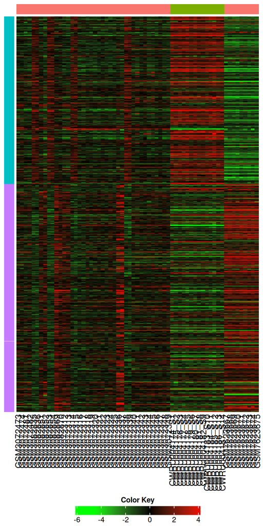

```r
if (!is.null(params$heat_data) && !is.null(params$heat_bar)) {
  heat_colors <- unlist(strsplit(params$heatmap_color_select, "-"))

  deg_heatmap(
    df = params$heat_data,
    bar = params$heat_bar,
    heatmap_color_select = heat_colors,
    cluster_rows = FALSE
  )
}
```

## Volcano Plot

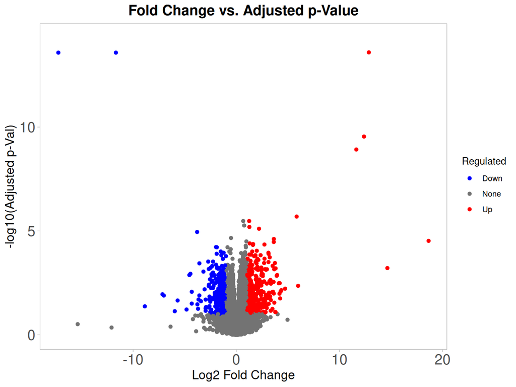

```r
if (!is.null(params$vol_data) && !is.null(params$vol_data$data)) {
  p <- plot_volcano(
    data = params$vol_data$data,
    plot_colors = params$plot_colors,
    anotate_genes = params$gene_labels_volcano
  )
  p <- refine_ggplot2(
    p = p,
    gridline = params$plot_grid_lines,
    ggplot2_theme = params$ggplot2_theme
  )
  print(p)
}
```